# THBP T6 Gender analysis

Bindoff, A.

2019-11-06 14:58:21

Reproducible R code and Supplementary Materials for Alty & Bindoff et al. (*in press*). Data available through the University of Tasmania Research Data Portal `thbp_t6_sex.rds` under CC-BY 4.0 (International) license.

## Data handling

Data were downloaded from THBP database on 2nd May 2019. Implausible outliers were removed (e.g obvious coding errors). Voluntary withdrawals and participants who met exclusion criteria were removed. Cognitive test scores were reversed and/transformed where appropriate, then standardized. The latent variable ‘prior cognitive reserve’ (PCR) was calculated as per Ward et al. (reported in-text as ‘CR’) [1]. R script used to clean data available on request (`minimal_reproducible_dataset.R`).

```r
long <- readRDS('thbp_t6_sex.rds') %>% filter(!is.na(pcr))
d0_baseline <- filter(long, phase_f == '1', !duplicated(idcode))
d0 <- arrange(long, idcode, phase) %>%
  group_by(idcode, phase_f) %>%
  filter(!duplicated(phase_f)) %>%
  ungroup()
```

## Demographics

### Test scores by phase

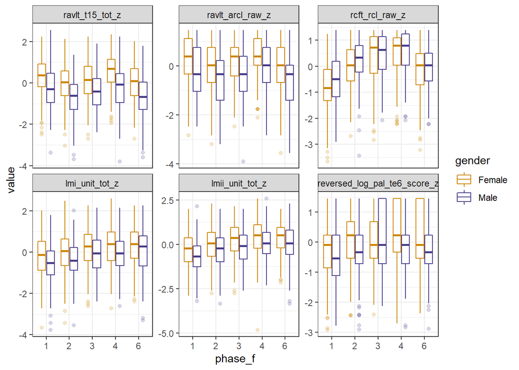

```r
ggplot(long, aes(x = phase_f, y = value, colour = gender)) +
  geom_boxplot(alpha = 0.2) +
  scale_colour_manual(values = c("orange3", "slateblue4")) +
  facet_wrap(~test, scales = "free_y") +
  theme_bw()
```

```r
  table1(~ age_1 + mhq_edschool + wtar_fsiq + apoe + pcr + group | gender, d0_baseline, digits = 3, overall = "Total")
```

|  | Female (n=378) | Male (n=178) | Total (n=556) |
| --- | --- | --- | --- |
| Age |  |  |  |
| Mean (SD) | 59.9 (6.57) | 61.0 (6.95) | 60.2 (6.71) |
| Median [Min, Max] | 59.0 [50.0, 78.0] | 61.0 [50.0, 78.0] | 60.0 [50.0, 78.0] |
| Education (years) |  |  |  |
| Mean (SD) | 11.2 (1.06) | 11.4 (0.955) | 11.2 (1.03) |
| Median [Min, Max] | 12.0 [7.00, 13.0] | 12.0 [9.00, 12.0] | 12.0 [7.00, 13.0] |
| WTAR FSIQ |  |  |  |
| Mean (SD) | 113 (5.38) | 112 (5.51) | 112 (5.42) |
| Median [Min, Max] | 114 [84.0, 123] | 114 [83.0, 119] | 114 [83.0, 123] |
| apoe |  |  |  |
| e4- | 210 (55.6%) | 95 (53.4%) | 305 (54.9%) |
| e4+ | 94 (24.9%) | 57 (32.0%) | 151 (27.2%) |
| Missing | 74 (19.6%) | 26 (14.6%) | 100 (18.0%) |
| Prior Cognitive Reserve (z) |  |  |  |
| Mean (SD) | -0.0890 (1.02) | 0.219 (0.914) | 0.00970 (0.994) |
| Median [Min, Max] | 0.00925 [-2.87, 2.41] | 0.211 [-2.08, 2.89] | 0.0551 [-2.87, 2.89] |
| Educational Intervention Group |  |  |  |
| Control | 78 (20.6%) | 45 (25.3%) | 123 (22.1%) |
| Experimental | 300 (79.4%) | 133 (74.7%) | 433 (77.9%) |

```r
  table1(~ gender + age_1 + apoe + group | phase_f, d0, overall = FALSE)
```

|  | 1 (n=556) | 2 (n=507) | 3 (n=476) | 4 (n=454) | 6 (n=396) |
| --- | --- | --- | --- | --- | --- |
| gender |  |  |  |  |  |
| Female | 378 (68.0%) | 343 (67.7%) | 318 (66.8%) | 304 (67.0%) | 265 (66.9%) |
| Male | 178 (32.0%) | 164 (32.3%) | 158 (33.2%) | 150 (33.0%) | 131 (33.1%) |
| Age |  |  |  |  |  |
| Mean (SD) | 60.2 (6.71) | 61.1 (6.70) | 62.2 (6.69) | 63.3 (6.64) | 65.1 (6.63) |
| Median [Min, Max] | 60.0 [50.0, 78.0] | 61.0 [50.0, 79.0] | 62.0 [51.0, 80.0] | 63.0 [52.0, 81.0] | 65.0 [55.0, 83.0] |
| apoe |  |  |  |  |  |
| e4- | 305 (54.9%) | 289 (57.0%) | 278 (58.4%) | 265 (58.4%) | 230 (58.1%) |
| e4+ | 151 (27.2%) | 142 (28.0%) | 133 (27.9%) | 129 (28.4%) | 117 (29.5%) |
| Missing | 100 (18.0%) | 76 (15.0%) | 65 (13.7%) | 60 (13.2%) | 49 (12.4%) |
| Educational Intervention Group |  |  |  |  |  |
| Control | 123 (22.1%) | 108 (21.3%) | 101 (21.2%) | 97 (21.4%) | 80 (20.2%) |
| Experimental | 433 (77.9%) | 399 (78.7%) | 375 (78.8%) | 357 (78.6%) | 316 (79.8%) |

#### Attrition

```r
# R = (# at final phase - # at beginning)/# at beginning
# r = (1+R)^(1/years of study)
# rate of attrition = 1-r

1-(1+(396-556)/556)^(1/5)
```

```
## [1] 0.06561883
```

## Age-related cohort effects

A thin-plate regression spline was used to estimate age and gender related cohort effects. This shows that CR varies little with age and gender, and not in a way which would explain age or gender related cognitive declines in our sample.

### Fig 1

```r
m1 <- gam(pcr ~ gender + s(age_1, bs = "tp", by = gender), method = "REML", data = d0_baseline)
```

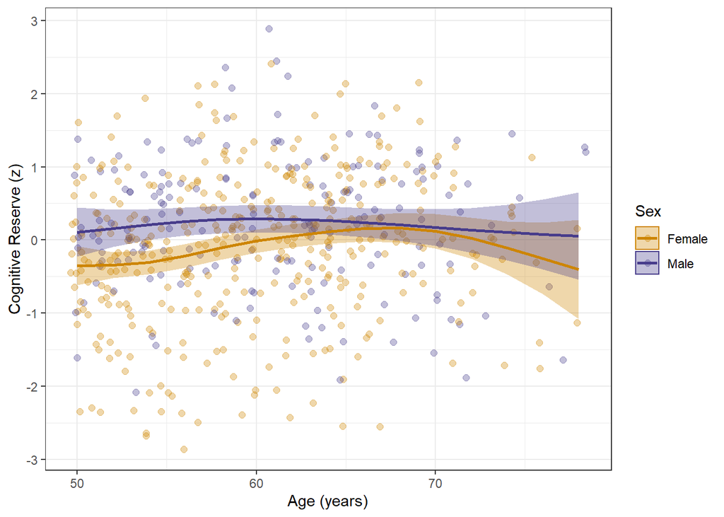

```r
summary(m0 <- lm(pcr ~ gender + age_1, data = d0_baseline))
```

```
##
## Call:
## lm(formula = pcr ~ gender + age_1, data = d0_baseline)
##
## Residuals:
##      Min       1Q   Median       3Q      Max
## -2.71931 -0.59410  0.05014  0.67458  2.66886
##
## Coefficients:
##             Estimate Std. Error t value Pr(>|t|)
## (Intercept) -0.98133    0.37576  -2.612  0.00926 **
## genderMale   0.29174    0.08933   3.266  0.00116 **
## age_1        0.01490    0.00622   2.396  0.01689 *
## ---
## Signif. codes:  0 '***' 0.001 '**' 0.01 '*' 0.05 '.' 0.1 ' ' 1
##
## Residual standard error: 0.9798 on 553 degrees of freedom
## Multiple R-squared:  0.03104,    Adjusted R-squared:  0.02754
## F-statistic: 8.859 on 2 and 553 DF,  p-value: 0.0001633
```

```r
confint(m0)
```

```
##                    2.5 %      97.5 %
## (Intercept) -1.719420687 -0.24323118
## genderMale   0.116275157  0.46721081
## age_1        0.002688045  0.02712281
```

In a linear regression analysis adjusting for age, Males had z = 0.29 higher CR than Females (p = .001), and adjusting for gender, CR increased (contrary to expectations) with age in this cohort which may reflect sampling bias (older participants who were willing to participate in the study may be more educated than their average peers of the same age).

```r
summary(m0 <- lm(wtar_fsiq ~ gender + age_1, data = d0_baseline))
```

```
##
## Call:
## lm(formula = wtar_fsiq ~ gender + age_1, data = d0_baseline)
##
## Residuals:
##     Min      1Q  Median      3Q     Max
## -30.132  -2.837   1.339   3.828  10.574
##
## Coefficients:
##             Estimate Std. Error t value Pr(>|t|)
## (Intercept) 105.4317     2.0598  51.185  < 2e-16 ***
## genderMale   -0.5982     0.4897  -1.222 0.222368
## age_1         0.1186     0.0341   3.477 0.000547 ***
## ---
## Signif. codes:  0 '***' 0.001 '**' 0.01 '*' 0.05 '.' 0.1 ' ' 1
##
## Residual standard error: 5.371 on 553 degrees of freedom
## Multiple R-squared:  0.02298,    Adjusted R-squared:  0.01945
## F-statistic: 6.503 on 2 and 553 DF,  p-value: 0.001616
```

```r
confint(m0)
```

```
##                    2.5 %      97.5 %
## (Intercept) 101.38570802 109.4776857
## genderMale   -1.56006151   0.3636505
## age_1         0.05157981   0.1855230
```

## Gender Interactions

### Splines

#### Model selection

```r
m1 <- glmmTMB::glmmTMB(value ~ phase_f*test + apoe + phase_f*group +
                         splines::ns(age_z, knots = c(-0.031), intercept = TRUE)*gender*test +
                         splines::ns(age_z, knots = c(-0.031), intercept = TRUE)*gender*pcr +
                         (phase_f|idcode) + (0 + test|idcode),
                       data = long,
                       REML = FALSE)
m2 <- glmmTMB::glmmTMB(value ~ phase_f*test + apoe + phase_f*group +
                         splines::ns(age_z, knots = c(-0.031), intercept = TRUE)*gender*test +
                         splines::ns(age_z, knots = c(-0.031), intercept = TRUE)*gender*pcr +
                         (phase_f + test|idcode),
                       data = long,
                       REML = FALSE)
m3 <- glmmTMB::glmmTMB(value ~ phase_f*test + apoe + phase_f*group +
                         splines::ns(age_z, knots = c(-0.031), intercept = TRUE)*gender*test +
                         splines::ns(age_z, knots = c(-0.031), intercept = TRUE)*gender*pcr +
                         ar1(0 + phase_f|idcode) + (0 + test|idcode),
                       data = long,
                       REML = FALSE)

library(glmmTMB)
long$phase_f <- numFactor(long$phase_f)
m4 <- glmmTMB::glmmTMB(value ~ phase_f*test + apoe + phase_f*group +
                         splines::ns(age_z, knots = c(-0.031), intercept = TRUE)*gender*test +
                         splines::ns(age_z, knots = c(-0.031), intercept = TRUE)*gender*pcr +
                         ou(phase_f + 0|idcode) + (test+ 0|idcode),
                       data = long,
                       REML = FALSE)
```

```r
# pcr*test  :    adjust for mean effect of CR on test performance (lang tests likely to benefit more than spatial)
# phase_f*test : adjust for mean practice effects unique to each test
# apoe  :        adjust for effect of apoe (questionable value)
# age x gender x pcr: the interaction of interest
# group :        adjust for mean effect of THBP intervention
# (phase + test|idcode)  : random effects of individual cognitive trajectory over time and individual test-specific cognitive performance not captured in fixed effects

# knots at median age_z
# system.time(m1.1 <- glmmTMB::glmmTMB(value ~ pcr*test + phase_f*test + apoe + phase_f*group +
#                          splines::ns(age_z, knots = c(-0.031), intercept = TRUE)*gender*splines::ns(pcr, knots = 0, intercept = TRUE)*test + (phase + test|idcode),
#                                    long,
#                        REML = FALSE))


# system.time(m1 <- lmer(value ~ pcr*test + phase_f*test + apoe + phase_f*group +
#                          splines::ns(age_z, knots = c(-0.031), intercept = TRUE)*gender*pcr*test + (phase_f + test|idcode),
#                                    long,
#                        REML = FALSE))  ## 22m
```

```r
system.time(m1 <- lmer(value ~ phase_f*test + apoe + phase_f*group +
                         splines::ns(age_z, knots = c(-0.031), intercept = TRUE)*gender*test +
                         splines::ns(age_z, knots = c(-0.031), intercept = TRUE)*gender*pcr +
                         (phase_f + test|idcode),
                       data = long,
                       REML = FALSE))  # 13min
```

```r
# test APOE x age x gender

system.time(m.apoe <- lme4::lmer(value ~ phase_f*test + phase_f*group +
                         age_z*pcr +
                         age_z*test +
                         age_z*apoe*gender +
                         (1|idcode),
                       data = long,
                       REML = FALSE))  #
```

```
##    user  system elapsed
##    0.89    0.00    0.89
```

```r
anova(m.apoe)
```

```
## Analysis of Variance Table
##                   Df Sum Sq Mean Sq  F value
## phase_f            4 294.85  73.713 132.2082
## test               5   3.04   0.607   1.0896
## group              1   5.97   5.969  10.7059
## age_z              1  48.67  48.668  87.2883
## pcr                1   4.95   4.952   8.8818
## apoe               1   0.08   0.077   0.1390
## gender             1  17.19  17.187  30.8257
## phase_f:test      20 412.96  20.648  37.0328
## phase_f:group      4   3.25   0.812   1.4571
## age_z:pcr          1   1.17   1.170   2.0989
## test:age_z         5  14.09   2.819   5.0553
## age_z:apoe         1   2.20   2.201   3.9482
## age_z:gender       1   1.09   1.086   1.9479
## apoe:gender        1   0.40   0.401   0.7188
## age_z:apoe:gender  1   0.06   0.064   0.1142
```

Set up some plotting functions and estimate from model

```r
m1 <- readRDS('m1_nl.rds')
p2 <- expand.grid(test = factor(levels(long$test)),
                    phase_f = factor(2),
                    group = factor("Control"),
                    phase = 2,
                    apoe = factor('e4-'),
                    gender = factor(unique(long$gender)),
                    pcr = round(quantile(d0_baseline$pcr, seq(0.1, 0.9, by = 0.2), na.rm = TRUE), 1),
                    age_z = seq(-1.6, 2.73, by = (2.73+1.6)/12),
                    idcode = NA)

p2$fit <- predict(m1, p2, re.form = NA)

xbar <- mean(d0_baseline$age_1)
sdx <- sd(d0_baseline$age_1)

p2$age_xi <- round(p2$age_z*sdx + xbar + as.numeric(p2$phase_f)-1, 1)

l1 <- dplyr::filter(long, phase_f %in% unique(p2$phase_f)) %>%
  select(age_z, pcr, value, gender, test, phase_f) %>%
  na.omit() %>%
  mutate(age_xi = age_z*sdx + xbar + as.numeric(phase_f)-1)

alpha_pcr <- function(d, pcr0, sd = 1){
  # capture anything below or above 10th/90th percentiles
  d$pcr[d$pcr < -1.4] <- -1.4
  d$pcr[d$pcr > 1.2] <- 1.2
  d$pcr0 <- dnorm(d$pcr, pcr0, sd)
  d$PCR <- pcr0
  d
}

l2 <- bind_rows(lapply(unique(p2$pcr), function(z) alpha_pcr(l1, z, sd = 0.3))) %>%
  mutate(PCR = factor(PCR, levels = c(-1.4, -0.4, 0.1, 0.6, 1.2), labels = c("10th percentile",
                                                                           "30th percentile",
                                                                           "50th percentile",
                                                                           "70th percentile",
                                                                           "90th percentile")))


p2$PCR <- factor(p2$pcr, levels = c(-1.4, -0.4, 0.1, 0.6, 1.2), labels = c("10th percentile",
                                                                           "30th percentile",
                                                                           "50th percentile",
                                                                           "70th percentile",
                                                                           "90th percentile"))
```

#### Fig 3 in ms

Highlight data-points from participants with PCR in the region on display (from top, 10th, 50th, 90th percentile of PCR)

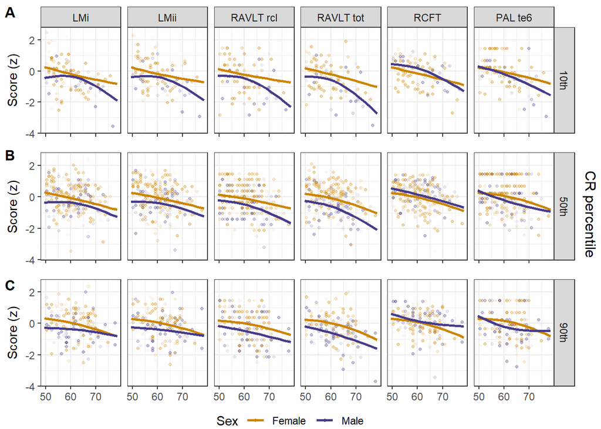

```r
plot_pcr <- function(x){
  ggplot(filter(p2, PCR == x), aes(x = age_xi, y = fit, colour = gender, group = gender)) +
      geom_point(data = filter(l2, PCR == x), size = 0.9, aes(y = value, x = age_xi, alpha = pcr0)) +
     geom_line(size = 1, aes(x = age_xi)) +
     scale_colour_manual(values = c("orange3", "slateblue4"), name = "Sex") +
      facet_grid(PCR~test, labeller = as_labeller(test_names)) +
     theme_bw() +
      scale_alpha_continuous(range = c(0, 0.33), guide = FALSE) +
    ylim(-3.7, 2.5) +
   ylab("Score (z)") +
   xlab("")
}

pl <- lapply(unique(p2$PCR), plot_pcr)
library(cowplot)
pabc <- plot_grid(pl[[1]]+theme(legend.position = 'none',
                                axis.text.x = element_blank(), plot.margin = margin(c(2, 2, 0, 2), unit = "mm")),
                        pl[[3]]+theme(legend.position = 'none',
                                      axis.text.x = element_blank(), plot.margin = margin(c(0, 2, 0, 2), unit = "mm"),
                                      strip.background.x = element_blank(),
                                      strip.text.x = element_blank()),
                        pl[[5]]+theme(legend.position = 'none', plot.margin = margin(c(0, 2, -2, 2), unit = "mm"),
                                      strip.background.x = element_blank(),
                                      strip.text.x = element_blank()),
          get_legend(pl[[5]]+theme(legend.position = 'bottom')),
          ncol = 1,
          rel_heights = c(1.40, 1.16, 1.21, 0.16),
          labels = c("A", "B", "C"),
          label_size = 12,
          vjust = c(1.6, .7, 1))

pabc <- gridExtra::grid.arrange(pabc, right = "CR percentile")
```

#### Figure 3.1 (animation, cannot be reproduced in ms)

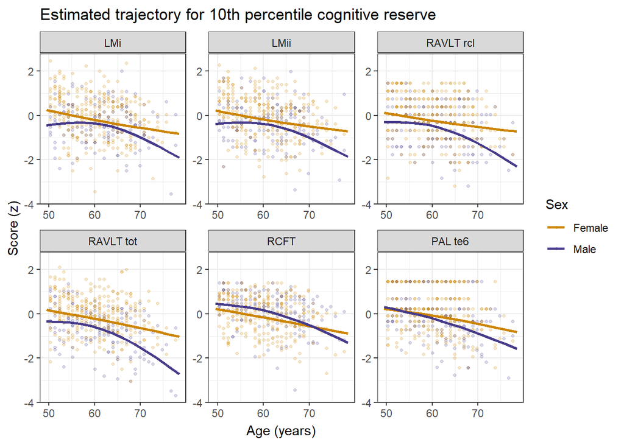

```r
library(gganimate)
pl <- ggplot(p2, aes(x = age_xi, y = fit, colour = gender, group = gender)) +
    geom_point(data = l1, alpha = 0.20, size = 0.9, aes(y = value, x = age_xi)) +
    geom_line(size = 1) +
    scale_colour_manual(values = c("orange3", "slateblue4"), name = "Sex") +
    facet_wrap(~test, ncol = 3, scales = "free", labeller = as_labeller(test_names)) +
    theme_bw() +
  ylab("Score (z)") +
  xlab("Age (years)") +
  transition_states(PCR) +
   ease_aes('linear') +
   view_follow() +
  labs(title = 'Estimated trajectory for {closest_state} cognitive reserve')

#animate(pl, renderer = ffmpeg_renderer(), width = 800, height = 450)
#anim_save('nonlinear_cr_animation.mp4')

pl
```

### Linear models

```r
# pcr*test  :    adjust for effect of education on test performance (lang tests likely to benefit more than spatial)
# phase_f*test : adjust for practice effects unique to each test
# apoe  :        adjust for effect of apoe (questionable value)
# group x phase : adjust for average effect of THBP experimental group
# age x gender x pcr x test : the interactions of interest - most likely under-powered?
# (phase + test|idcode)  : random effects of individual cognitive trajectory over time and individual test-specific cognitive performance not captured in fixed effects


system.time(m2 <- lmer(value ~ phase_f*test + apoe + phase_f*group +
                         age_z*gender*pcr*test + (phase_f + test|idcode),
                                   long,
                       REML = FALSE))
```

```r
# 3-way interactions informative and more achievable with given data
system.time(m2 <- lmer(value ~ phase_f*test + apoe + phase_f*group +
                         age_z*gender*test +
                         age_z*gender*pcr + (phase_f + test|idcode),
                                   long,
                       REML = FALSE))
```

```
##    user  system elapsed
##  607.73   61.90  670.02
```

The effect of PCR in the age x PCR x gender x test is shown plotted below. PCR is plotted in the rows at the 10th, 50th, and 90th percentiles.

```r
p2$fit <- predict(m2, p2, re.form = NA)
```

#### Fig 2 in ms

Highlight data-points from participants with PCR in the region on display (from top, 10th, 50th, 90th percentile of PCR)

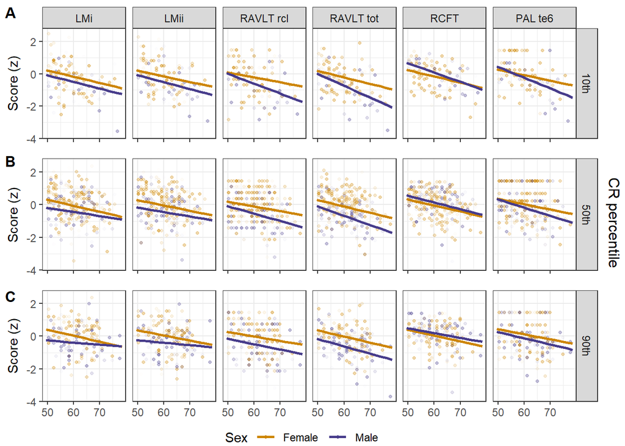

#### Fig 4 in ms

```r
p2 <- expand.grid(test = factor(levels(long$test)),
                  phase_f = factor(2),
                  group = factor("Control"),
                  phase = 2,
                  apoe = factor('e4-'),
                  gender = factor(unique(long$gender)),
                  pcr = round(quantile(d0_baseline$pcr, seq(0.1, 0.9, by = 0.4), na.rm = TRUE), 1),
                  age_z = c(-1.525, -.776, 0.7175, 2.212, 2.96),
                  idcode = NA)
xbar <- mean(d0_baseline$age_1)
sdx <- sd(d0_baseline$age_1)
p2$age_xi <- round(p2$age_z*sdx + xbar + as.numeric(p2$phase_f)-1, 1)
```

Bootstrap confidence intervals (!!warning, took 17hours on 4 CPUs!!)

```r
predFun <- function(x) predict(x, newdata = p2, re.form = NA)

system.time(fit_m1 <- bootMer(m1, FUN = predFun, nsim = 100, parallel = "multicore", ncpus = 4L)) #9.6h
#saveRDS(fit_m1, file = "bootfitm1.rds")

system.time(fit_m2 <- bootMer(m2, FUN = predFun, nsim = 100, parallel = "multicore", ncpus = 4L)) #8h
#saveRDS(fit_m2, file = "bootfitm2.rds")
```

```r
z <- cbind(p2, t(fit_m1$t))



z0 <- arrange(z, test, age_xi, pcr, gender) %>%
  select(11:110)

z1 <- data.frame(matrix(rep(0, 90*100), nrow = 90))
for(i in seq(1, nrow(z0)-1, by = 2)){
  z1[(i+1)/2,] <- z0[i,]-z0[i+1, ]
}

z0 <- arrange(z, test, age_xi, pcr, gender) %>%
  select(test, age_xi, pcr, gender) %>%
  filter(gender == "Male")

bb_ci <- as.data.frame(t(apply(z1,1,quantile,c(0.025,0.975))))
names(bb_ci) <- c("lwr","upr")
Estimate <- apply(z1, 1, mean)
z0 <- cbind(z0, Estimate, bb_ci)


bb_ci <- as.data.frame(t(apply(fit_m1$t, 2, quantile, c(0.025, 0.975))))
names(bb_ci) <- c("lwr","upr")
Estimate <- apply(fit_m1$t, 2, mean)
p2 <- cbind(p2, Estimate)

z2 <- p2 %>% arrange(test, pcr, age_xi, gender) %>%
  group_by(test, age_xi, pcr, gender) %>%
  tidyr::spread(gender, Estimate) %>%
  mutate(diff = Male - Female) %>%
  ungroup()

p2 <- cbind(p2, bb_ci)


z3 <- left_join(z2, z0, by = c('age_xi', 'pcr', 'test')) %>%
  filter(!age_xi %in% c(50, 80))

p3 <- p2 %>% filter(!age_xi %in% c(50, 80)) %>%
  group_by(test, age_xi, pcr, gender) %>%
  mutate(est = paste0(round(Estimate, 2), ' [', round(lwr, 2), ', ', round(upr, 2), ']')) %>%
  select(test, pcr, age_xi, est) %>%
  tidyr::spread(gender, est) %>%
  ungroup() %>%
  left_join(select(z3, test, pcr, age_xi, Estimate, lwr, upr), by = c('test','pcr', 'age_xi')) %>%
  mutate(Difference = paste0(round(Estimate, 2), ' [', round(lwr, 2), ', ', round(upr, 2), ']')) %>%
  select(-c(Estimate, lwr, upr)) %>%
  arrange(age_xi)
```

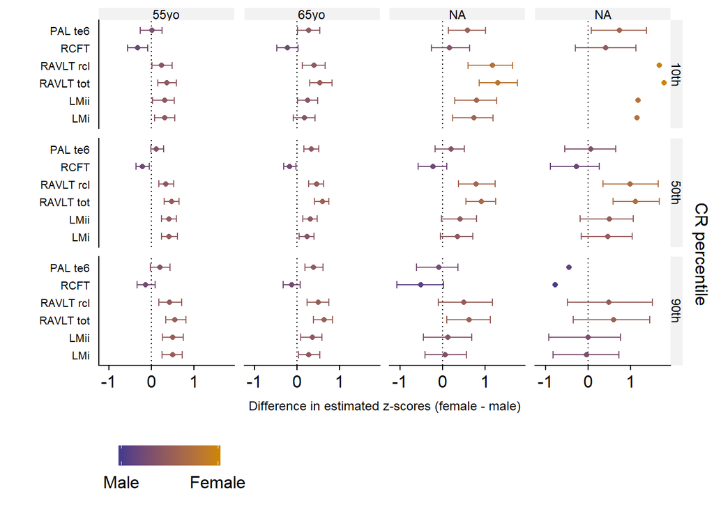

```r
test_names <- c(
  `ravlt_t15_tot_z` = "RAVLT tot",
  `ravlt_arcl_raw_z` = "RAVLT rcl",
  `rcft_rcl_raw_z` = "RCFT",
  `lmi_unit_tot_z` = "LMi",
  `lmii_unit_tot_z` = "LMii",
  `reversed_log_pal_te6_score_z` = "PAL te6",
  `55` = "55yo",
  `65` = "65yo",
  `75` = "75yo",
  `-1.4` = "10th",
  `-0.4` = "30th",
  `0.1` = "50th",
  `0.6` = "70th",
  `1.2` = "90th"
)

z4 <- left_join(p3, select(z3, test, pcr, age_xi, Estimate, lwr, upr), by = c('test','age_xi','pcr')) %>%
  mutate(bootstrap = paste(test, Female, Male),
         test = case_when(test == 'reversed_log_pal_te6_score_z' ~ 'PAL te6',
                          test == 'rcft_rcl_raw_z' ~ 'RCFT',
                          test == 'ravlt_t15_tot_z' ~ 'RAVLT tot',
                          test == 'ravlt_arcl_raw_z' ~ 'RAVLT rcl',
                          test == 'lmii_unit_tot_z' ~ 'LMii',
                          test == 'lmi_unit_tot_z' ~ 'LMi')) %>%
  mutate(test = factor(test, levels = c('LMi', 'LMii', 'RAVLT tot', 'RAVLT rcl', 'RCFT', 'PAL te6')))

fig4 <- ggplot(z4, aes(y = Estimate, x = test, colour = Estimate)) +
  geom_hline(yintercept = 0, linetype = 'dotted') +
  geom_errorbar(aes(ymin = lwr, ymax = upr), width = 0.4) +
  geom_point() +
  scale_color_gradient(low = "slateblue4", high = "orange3", breaks = range(z4$Estimate), labels = c("Male", "Female"), name = '') +
  facet_grid(pcr~age_xi,labeller = as_labeller(test_names)) +
  ylab('Difference in estimated z-scores (female - male)') +
  xlab('') +
  ylim(-1.1, 1.8) +
  theme(axis.text.y = element_text(size = 8),
        axis.title.x = element_text(size = 9),
        plot.margin = margin(c(2,2,2,2), unit = 'mm'),
        panel.background = element_blank(),
        strip.background = element_rect(fill = "grey95"),
        strip.text = element_text(size = 9),
        legend.position = 'bottom',
        axis.ticks.y = element_blank()) +
  coord_flip()

library(gtable)
library(gridExtra)

fig4 <- grid.arrange(fig4, ncol = 1, right = "CR percentile")
```

```r
print(fig4)
```

## Table S1 (coefficients)

Standardized coefficients with 95% CIs for linear and non-linear models (side-by-side)

```r
sjPlot::tab_model(m2, m1, digits = 3)
```

|  | value |  |  | value |  |  |
| --- | --- | --- | --- | --- | --- | --- |
| Predictors | Estimates | CI | p | Estimates | CI | p |
| (Intercept) | 0.195 | 0.047 – 0.344 | **0.010** | -4.236 | -5.792 – -2.679 | **<0.001** |
| phase f 2 | -0.315 | -0.427 – -0.203 | **<0.001** | -0.317 | -0.429 – -0.205 | **<0.001** |
| phase f 3 | -0.130 | -0.252 – -0.008 | **0.037** | -0.132 | -0.254 – -0.010 | **0.034** |
| phase f 4 | 0.259 | 0.134 – 0.385 | **<0.001** | 0.259 | 0.134 – 0.385 | **<0.001** |
| phase f 6 | -0.232 | -0.369 – -0.095 | **0.001** | -0.227 | -0.363 – -0.090 | **0.001** |
| ravlt arcl raw z | -0.065 | -0.147 – 0.018 | 0.125 | 1.328 | 0.208 – 2.449 | **0.020** |
| rcft rcl raw z | -1.079 | -1.195 – -0.962 | **<0.001** | -0.748 | -2.611 – 1.114 | 0.431 |
| lmi unit tot z | -0.468 | -0.576 – -0.360 | **<0.001** | 0.194 | -1.478 – 1.867 | 0.820 |
| lmii unit tot z | -0.530 | -0.637 – -0.422 | **<0.001** | 0.527 | -1.143 – 2.198 | 0.536 |
| reversed log pal te 6 score z | -0.465 | -0.578 – -0.353 | **<0.001** | 0.005 | -1.776 – 1.786 | 0.996 |
| e 4+ | 0.052 | -0.052 – 0.156 | 0.325 | 0.048 | -0.055 – 0.151 | 0.364 |
| Experimental | 0.060 | -0.078 – 0.198 | 0.393 | 0.075 | -0.064 – 0.213 | 0.291 |
| age z | -0.258 | -0.340 – -0.176 | **<0.001** |  |  |  |
| Male | -0.570 | -0.719 – -0.422 | **<0.001** | -3.028 | -5.301 – -0.756 | **0.009** |
| Prior Cognitive Reserve(z) | 0.080 | 0.020 – 0.141 | **0.010** | -0.166 | -1.176 – 0.843 | 0.747 |
| phase_f2:testravlt_arcl_raw_z | 0.073 | -0.039 – 0.184 | 0.200 | 0.075 | -0.036 – 0.187 | 0.186 |
| phase_f3:testravlt_arcl_raw_z | 0.003 | -0.108 – 0.115 | 0.953 | 0.007 | -0.104 – 0.118 | 0.903 |
| phase_f4:testravlt_arcl_raw_z | -0.049 | -0.162 – 0.065 | 0.402 | -0.045 | -0.159 – 0.068 | 0.435 |
| phase_f6:testravlt_arcl_raw_z | 0.001 | -0.120 – 0.123 | 0.982 | 0.003 | -0.119 – 0.124 | 0.965 |
| phase_f2:testrcft_rcl_raw_z | 1.142 | 1.029 – 1.255 | **<0.001** | 1.144 | 1.031 – 1.257 | **<0.001** |
| phase_f3:testrcft_rcl_raw_z | 1.303 | 1.189 – 1.417 | **<0.001** | 1.305 | 1.191 – 1.420 | **<0.001** |
| phase_f4:testrcft_rcl_raw_z | 1.074 | 0.955 – 1.192 | **<0.001** | 1.075 | 0.956 – 1.195 | **<0.001** |
| phase_f6:testrcft_rcl_raw_z | 0.929 | 0.796 – 1.062 | **<0.001** | 0.927 | 0.794 – 1.061 | **<0.001** |
| phase_f2:testlmi_unit_tot_z | 0.511 | 0.398 – 0.623 | **<0.001** | 0.513 | 0.401 – 0.626 | **<0.001** |
| phase_f3:testlmi_unit_tot_z | 0.554 | 0.441 – 0.667 | **<0.001** | 0.557 | 0.444 – 0.671 | **<0.001** |
| phase_f4:testlmi_unit_tot_z | 0.259 | 0.142 – 0.377 | **<0.001** | 0.263 | 0.145 – 0.380 | **<0.001** |
| phase_f6:testlmi_unit_tot_z | 0.759 | 0.630 – 0.889 | **<0.001** | 0.762 | 0.632 – 0.892 | **<0.001** |
| phase_f2:testlmii_unit_tot_z | 0.596 | 0.484 – 0.709 | **<0.001** | 0.599 | 0.487 – 0.712 | **<0.001** |
| phase_f3:testlmii_unit_tot_z | 0.664 | 0.551 – 0.777 | **<0.001** | 0.668 | 0.555 – 0.782 | **<0.001** |

[output cut: 82 more lines]

## Table S2

These confidence intervals were estimated in preparation for Fig 4 in ms.

```r
sjPlot::tab_df(p3)
```

| test | pcr | age_xi | Female | Male | Difference |
| --- | --- | --- | --- | --- | --- |
| 1 | -1.40 | 55.00 | 0.01 [-0.17, 0.2] | -0.29 [-0.55, -0.06] | 0.3 [0.07, 0.55] |
| 1 | 0.10 | 55.00 | 0.11 [-0.06, 0.28] | -0.3 [-0.48, -0.12] | 0.41 [0.24, 0.6] |
| 1 | 1.20 | 55.00 | 0.18 [-0.03, 0.39] | -0.31 [-0.54, -0.06] | 0.49 [0.25, 0.72] |
| 2 | -1.40 | 55.00 | 0.01 [-0.14, 0.19] | -0.29 [-0.55, -0.05] | 0.3 [0.01, 0.54] |
| 2 | 0.10 | 55.00 | 0.11 [-0.04, 0.29] | -0.3 [-0.51, -0.09] | 0.41 [0.23, 0.58] |
| 2 | 1.20 | 55.00 | 0.19 [-0.02, 0.42] | -0.31 [-0.58, -0.04] | 0.49 [0.25, 0.75] |
| 3 | -1.40 | 55.00 | -0.06 [-0.23, 0.1] | -0.29 [-0.57, -0.02] | 0.23 [0, 0.48] |
| 3 | 0.10 | 55.00 | 0.04 [-0.16, 0.23] | -0.3 [-0.52, -0.1] | 0.34 [0.18, 0.52] |
| 3 | 1.20 | 55.00 | 0.11 [-0.11, 0.33] | -0.31 [-0.59, -0.04] | 0.42 [0.18, 0.71] |
| 4 | -1.40 | 55.00 | -0.02 [-0.19, 0.15] | -0.38 [-0.61, -0.11] | 0.36 [0.14, 0.59] |
| 4 | 0.10 | 55.00 | 0.08 [-0.09, 0.25] | -0.39 [-0.57, -0.17] | 0.47 [0.3, 0.64] |
| 4 | 1.20 | 55.00 | 0.15 [-0.06, 0.35] | -0.4 [-0.65, -0.12] | 0.55 [0.33, 0.81] |
| 5 | -1.40 | 55.00 | 0.04 [-0.12, 0.23] | 0.36 [0.07, 0.63] | -0.33 [-0.57, -0.09] |
| 5 | 0.10 | 55.00 | 0.14 [0, 0.31] | 0.36 [0.16, 0.51] | -0.22 [-0.37, -0.05] |
| 5 | 1.20 | 55.00 | 0.21 [0.01, 0.41] | 0.35 [0.08, 0.56] | -0.14 [-0.34, 0.08] |
| 6 | -1.40 | 55.00 | 0.09 [-0.08, 0.27] | 0.08 [-0.19, 0.34] | 0.01 [-0.26, 0.25] |
| 6 | 0.10 | 55.00 | 0.19 [0.03, 0.33] | 0.08 [-0.12, 0.24] | 0.11 [-0.01, 0.28] |
| 6 | 1.20 | 55.00 | 0.26 [0.06, 0.44] | 0.07 [-0.23, 0.24] | 0.19 [-0.04, 0.43] |
| 1 | -1.40 | 65.00 | -0.39 [-0.56, -0.16] | -0.56 [-0.8, -0.35] | 0.17 [-0.09, 0.42] |
| 1 | 0.10 | 65.00 | -0.26 [-0.42, -0.07] | -0.49 [-0.67, -0.28] | 0.23 [0.04, 0.39] |
| 1 | 1.20 | 65.00 | -0.16 [-0.33, 0.03] | -0.43 [-0.62, -0.2] | 0.27 [0.04, 0.53] |
| 2 | -1.40 | 65.00 | -0.34 [-0.5, -0.12] | -0.59 [-0.84, -0.38] | 0.25 [0.02, 0.49] |
| 2 | 0.10 | 65.00 | -0.21 [-0.34, -0.01] | -0.52 [-0.72, -0.33] | 0.31 [0.13, 0.47] |
| 2 | 1.20 | 65.00 | -0.11 [-0.29, 0.11] | -0.47 [-0.71, -0.22] | 0.36 [0.08, 0.59] |
| 3 | -1.40 | 65.00 | -0.37 [-0.52, -0.18] | -0.77 [-0.98, -0.51] | 0.4 [0.13, 0.66] |
| 3 | 0.10 | 65.00 | -0.24 [-0.4, -0.06] | -0.7 [-0.91, -0.53] | 0.46 [0.27, 0.62] |
| 3 | 1.20 | 65.00 | -0.14 [-0.34, 0.08] | -0.64 [-0.89, -0.41] | 0.5 [0.24, 0.75] |
| 4 | -1.40 | 65.00 | -0.42 [-0.6, -0.22] | -0.96 [-1.15, -0.75] | 0.54 [0.3, 0.82] |
| 4 | 0.10 | 65.00 | -0.29 [-0.45, -0.11] | -0.89 [-1.09, -0.71] | 0.6 [0.41, 0.75] |
| 4 | 1.20 | 65.00 | -0.2 [-0.37, -0.01] | -0.84 [-1.08, -0.61] | 0.64 [0.38, 0.84] |
| 5 | -1.40 | 65.00 | -0.35 [-0.52, -0.2] | -0.11 [-0.33, 0.13] | -0.23 [-0.48, 0.02] |
| 5 | 0.10 | 65.00 | -0.21 [-0.36, -0.05] | -0.04 [-0.2, 0.12] | -0.17 [-0.31, -0.03] |
| 5 | 1.20 | 65.00 | -0.12 [-0.29, 0.08] | 0.01 [-0.19, 0.22] | -0.13 [-0.33, 0.08] |
| 6 | -1.40 | 65.00 | -0.23 [-0.44, -0.05] | -0.51 [-0.75, -0.28] | 0.28 [0.01, 0.53] |
| 6 | 0.10 | 65.00 | -0.1 [-0.27, 0.09] | -0.44 [-0.67, -0.27] | 0.34 [0.16, 0.51] |
| 6 | 1.20 | 65.00 | 0 [-0.17, 0.21] | -0.39 [-0.6, -0.15] | 0.38 [0.19, 0.61] |
| 1 | -1.40 | 75.10 | -0.74 [-1.12, -0.39] | -1.49 [-1.87, -1.08] | 0.74 [0.24, 1.19] |
| 1 | 0.10 | 75.10 | -0.69 [-0.99, -0.41] | -1.04 [-1.35, -0.73] | 0.35 [-0.05, 0.71] |
| 1 | 1.20 | 75.10 | -0.64 [-1.03, -0.25] | -0.71 [-1.12, -0.29] | 0.07 [-0.41, 0.56] |
| 2 | -1.40 | 75.10 | -0.66 [-1.01, -0.34] | -1.46 [-1.91, -1.07] | 0.8 [0.29, 1.28] |
| 2 | 0.10 | 75.10 | -0.6 [-0.86, -0.35] | -1.02 [-1.47, -0.69] | 0.41 [-0.03, 0.8] |
| 2 | 1.20 | 75.10 | -0.56 [-0.99, -0.18] | -0.69 [-1.16, -0.34] | 0.13 [-0.44, 0.68] |
| 3 | -1.40 | 75.10 | -0.65 [-0.96, -0.34] | -1.82 [-2.18, -1.43] | 1.18 [0.6, 1.65] |
| 3 | 0.10 | 75.10 | -0.59 [-0.84, -0.3] | -1.38 [-1.69, -1.09] | 0.79 [0.38, 1.24] |
| 3 | 1.20 | 75.10 | -0.55 [-0.92, -0.14] | -1.05 [-1.43, -0.66] | 0.5 [-0.1, 1.18] |
| 4 | -1.40 | 75.10 | -0.89 [-1.21, -0.56] | -2.19 [-2.57, -1.78] | 1.3 [0.87, 1.77] |
| 4 | 0.10 | 75.10 | -0.83 [-1.1, -0.6] | -1.75 [-2.06, -1.46] | 0.92 [0.55, 1.26] |
| 4 | 1.20 | 75.10 | -0.79 [-1.19, -0.47] | -1.42 [-1.81, -1.04] | 0.63 [0.1, 1.13] |
| 5 | -1.40 | 75.10 | -0.76 [-1.15, -0.41] | -0.92 [-1.34, -0.55] | 0.16 [-0.26, 0.64] |
| 5 | 0.10 | 75.10 | -0.7 [-0.99, -0.43] | -0.48 [-0.77, -0.12] | -0.22 [-0.57, 0.1] |
| 5 | 1.20 | 75.10 | -0.66 [-1.06, -0.32] | -0.15 [-0.57, 0.29] | -0.51 [-1.07, 0.02] |
| 6 | -1.40 | 75.10 | -0.67 [-1, -0.36] | -1.26 [-1.63, -0.85] | 0.59 [0.14, 1.02] |
| 6 | 0.10 | 75.10 | -0.61 [-0.85, -0.35] | -0.81 [-1.1, -0.49] | 0.2 [-0.17, 0.52] |
| 6 | 1.20 | 75.10 | -0.57 [-0.93, -0.21] | -0.49 [-0.87, -0.06] | -0.09 [-0.61, 0.37] |
| 1 | -1.40 | 80.10 | -0.91 [-1.42, -0.41] | -2.07 [-2.65, -1.4] | 1.16 [0.33, 1.85] |
| 1 | 0.10 | 80.10 | -0.91 [-1.34, -0.54] | -1.38 [-1.82, -0.95] | 0.47 [-0.15, 1.04] |
| 1 | 1.20 | 80.10 | -0.91 [-1.48, -0.29] | -0.88 [-1.49, -0.21] | -0.03 [-0.82, 0.72] |
| 2 | -1.40 | 80.10 | -0.81 [-1.37, -0.33] | -2 [-2.61, -1.38] | 1.19 [0.38, 1.9] |
| 2 | 0.10 | 80.10 | -0.81 [-1.18, -0.41] | -1.31 [-1.9, -0.85] | 0.5 [-0.18, 1.06] |
| 2 | 1.20 | 80.10 | -0.81 [-1.41, -0.25] | -0.81 [-1.45, -0.27] | 0 [-0.93, 0.76] |
| 3 | -1.40 | 80.10 | -0.78 [-1.27, -0.26] | -2.46 [-2.97, -1.82] | 1.68 [0.84, 2.46] |
| 3 | 0.10 | 80.10 | -0.78 [-1.18, -0.32] | -1.77 [-2.21, -1.26] | 0.99 [0.36, 1.66] |
| 3 | 1.20 | 80.10 | -0.78 [-1.37, -0.16] | -1.27 [-1.85, -0.61] | 0.49 [-0.48, 1.52] |
| 4 | -1.40 | 80.10 | -1.13 [-1.6, -0.64] | -2.93 [-3.53, -2.3] | 1.8 [1.13, 2.52] |
| 4 | 0.10 | 80.10 | -1.13 [-1.51, -0.79] | -2.24 [-2.73, -1.75] | 1.11 [0.59, 1.68] |
| 4 | 1.20 | 80.10 | -1.13 [-1.65, -0.67] | -1.74 [-2.35, -1.19] | 0.61 [-0.34, 1.46] |
| 5 | -1.40 | 80.10 | -0.97 [-1.56, -0.43] | -1.39 [-2.08, -0.85] | 0.42 [-0.29, 1.12] |
| 5 | 0.10 | 80.10 | -0.97 [-1.36, -0.58] | -0.7 [-1.21, -0.13] | -0.27 [-0.88, 0.26] |
| 5 | 1.20 | 80.10 | -0.97 [-1.54, -0.46] | -0.2 [-0.9, 0.5] | -0.77 [-1.7, 0.03] |
| 6 | -1.40 | 80.10 | -0.91 [-1.4, -0.42] | -1.66 [-2.25, -1.05] | 0.75 [0.07, 1.38] |
| 6 | 0.10 | 80.10 | -0.91 [-1.25, -0.51] | -0.98 [-1.44, -0.49] | 0.06 [-0.55, 0.65] |
| 6 | 1.20 | 80.10 | -0.91 [-1.46, -0.32] | -0.47 [-1.06, 0.2] | -0.44 [-1.32, 0.33] |

## Table S3

Estimated coefficients for a model of age x gender x APOE interactions.

```r
sjPlot::tab_model(m.apoe)
```

|  | value |  |  |
| --- | --- | --- | --- |
| Predictors | Estimates | CI | p |
| (Intercept) | 0.10 | -0.05 – 0.24 | 0.193 |
| phase f 2 | -0.31 | -0.44 – -0.19 | **<0.001** |
| phase f 3 | -0.14 | -0.27 – -0.01 | **0.033** |
| phase f 4 | 0.25 | 0.12 – 0.38 | **<0.001** |
| phase f 6 | -0.22 | -0.37 – -0.08 | **0.003** |
| ravlt arcl raw z | -0.02 | -0.12 – 0.08 | 0.724 |
| rcft rcl raw z | -0.80 | -0.90 – -0.71 | **<0.001** |
| lmi unit tot z | -0.39 | -0.48 – -0.29 | **<0.001** |
| lmii unit tot z | -0.46 | -0.56 – -0.36 | **<0.001** |
| reversed log pal te 6 score z | -0.33 | -0.43 – -0.24 | **<0.001** |
| Experimental | 0.04 | -0.10 – 0.18 | 0.557 |
| age z | -0.34 | -0.41 – -0.26 | **<0.001** |
| Prior Cognitive Reserve(z) | 0.09 | 0.04 – 0.15 | **<0.001** |
| e 4+ | 0.08 | -0.06 – 0.21 | 0.272 |
| Male | -0.27 | -0.41 – -0.13 | **<0.001** |
| phase_f2:testravlt_arcl_raw_z | 0.07 | -0.07 – 0.22 | 0.337 |
| phase_f3:testravlt_arcl_raw_z | 0.00 | -0.14 – 0.15 | 0.968 |
| phase_f4:testravlt_arcl_raw_z | -0.05 | -0.20 – 0.09 | 0.483 |
| phase_f6:testravlt_arcl_raw_z | -0.01 | -0.16 – 0.15 | 0.925 |
| phase_f2:testrcft_rcl_raw_z | 1.13 | 0.98 – 1.27 | **<0.001** |
| phase_f3:testrcft_rcl_raw_z | 1.30 | 1.16 – 1.45 | **<0.001** |
| phase_f4:testrcft_rcl_raw_z | 1.07 | 0.93 – 1.22 | **<0.001** |
| phase_f6:testrcft_rcl_raw_z | 0.88 | 0.73 – 1.04 | **<0.001** |
| phase_f2:testlmi_unit_tot_z | 0.52 | 0.37 – 0.66 | **<0.001** |
| phase_f3:testlmi_unit_tot_z | 0.57 | 0.42 – 0.71 | **<0.001** |
| phase_f4:testlmi_unit_tot_z | 0.28 | 0.13 – 0.43 | **<0.001** |
| phase_f6:testlmi_unit_tot_z | 0.77 | 0.61 – 0.93 | **<0.001** |
| phase_f2:testlmii_unit_tot_z | 0.60 | 0.46 – 0.75 | **<0.001** |
| phase_f3:testlmii_unit_tot_z | 0.68 | 0.53 – 0.82 | **<0.001** |
| phase_f4:testlmii_unit_tot_z | 0.41 | 0.26 – 0.56 | **<0.001** |
| phase_f6:testlmii_unit_tot_z | 0.86 | 0.71 – 1.02 | **<0.001** |
| phase_f2:testreversed_log_pal_te6_score_z | 0.60 | 0.45 – 0.74 | **<0.001** |
| phase_f3:testreversed_log_pal_te6_score_z | 0.47 | 0.32 – 0.61 | **<0.001** |
| phase_f4:testreversed_log_pal_te6_score_z | 0.17 | 0.02 – 0.31 | **0.027** |
| phase_f6:testreversed_log_pal_te6_score_z | 0.55 | 0.40 – 0.71 | **<0.001** |
| phase_f2:groupExperimental | -0.04 | -0.14 – 0.06 | 0.421 |
| phase_f3:groupExperimental | -0.01 | -0.11 – 0.10 | 0.918 |
| phase_f4:groupExperimental | 0.03 | -0.08 – 0.13 | 0.617 |
| phase_f6:groupExperimental | 0.09 | -0.02 – 0.20 | 0.109 |
| age_z:pcr | 0.03 | -0.01 – 0.07 | 0.104 |
| testravlt_arcl_raw_z:age_z | 0.08 | 0.03 – 0.13 | **0.002** |
| testrcft_rcl_raw_z:age_z | 0.10 | 0.05 – 0.15 | **<0.001** |
| testlmi_unit_tot_z:age_z | 0.10 | 0.05 – 0.15 | **<0.001** |
| testlmii_unit_tot_z:age_z | 0.11 | 0.06 – 0.16 | **<0.001** |
| testreversed_log_pal_te6_score_z:age_z | 0.08 | 0.03 – 0.13 | **0.003** |
| age_z:apoee4+ | 0.10 | -0.00 – 0.20 | 0.061 |
| age_z:genderMale | -0.05 | -0.15 – 0.05 | 0.321 |
| apoee4+:genderMale | -0.10 | -0.33 – 0.13 | 0.402 |
| age_z:apoee4+:genderMale | -0.03 | -0.21 – 0.15 | 0.735 |
| Random Effects |  |  |  |
| σ<sup>2</sup> | 0.56 |  |  |
| τ<sub>00</sub> <sub>idcode</sub> | 0.29 |  |  |
| ICC | 0.34 |  |  |
| N <sub>idcode</sub> | 457 |  |  |
| Observations | 11276 |  |  |
| Marginal R<sup>2</sup> / Conditional R<sup>2</sup> | 0.161 / 0.447 |  |  |

## References cited in Supplementary Materials

[1] Ward, D. D., Summers, M. J., Saunders, N. L., & Vickers, J. C. (2015). Modeling cognitive reserve in healthy middle-aged and older adults: the Tasmanian Healthy Brain Project. International Psychogeriatrics, 27(4), 579-589.